# Bivariate data, part 1: Building and checking a model

S470/670

Spring 2017

**READ: Cleveland pp. 86–119.**

### Ganglion data

Load the usual:

```r
load("lattice.RData")
library(ggplot2)
```

A ganglion is a nerve cell cluster. The data set `ganglion` contains data on ganglia in the retina of 14 cat fetuses. There are two variables:

- `area` is retinal area (in mm$^2$)
- `cp.ratio` is the ratio of ganglion cell density in the center of the retina to the ganglion cell density in the periphery (edge) of the retina.

We draw a scatterplot:

```r
ganglion.gg = ggplot(ganglion, aes(x=area, y=cp.ratio)) + geom_point()
```

Let’s add a smooth curve to the plot.

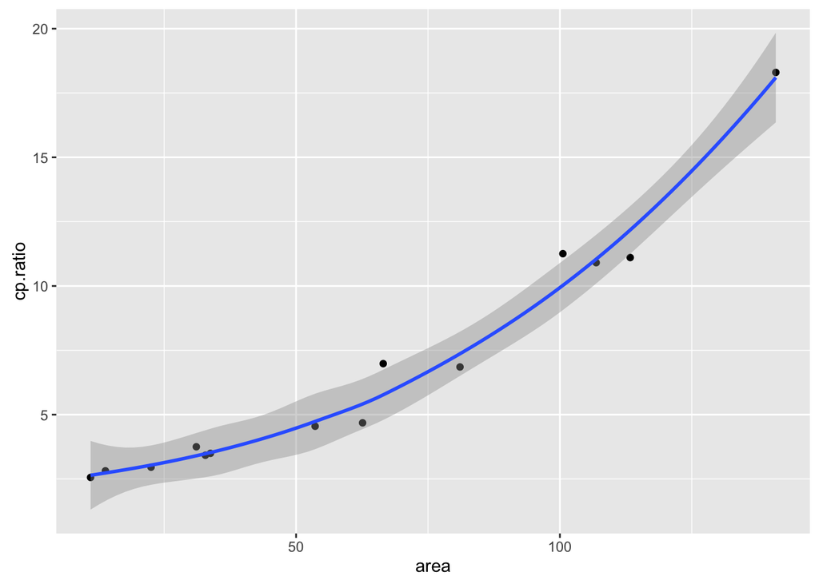

```r
ganglion.gg + geom_smooth()
```

By default, the curve is fitted using the “loess” method; we’ll talk more about this method later. The 95% confidence bands are for the fit, not for predictions (so we do not expect 95% of the data to be contained in the shaded area.)

Visually, we see the loess fit is quite curved. How well would a straight line do?

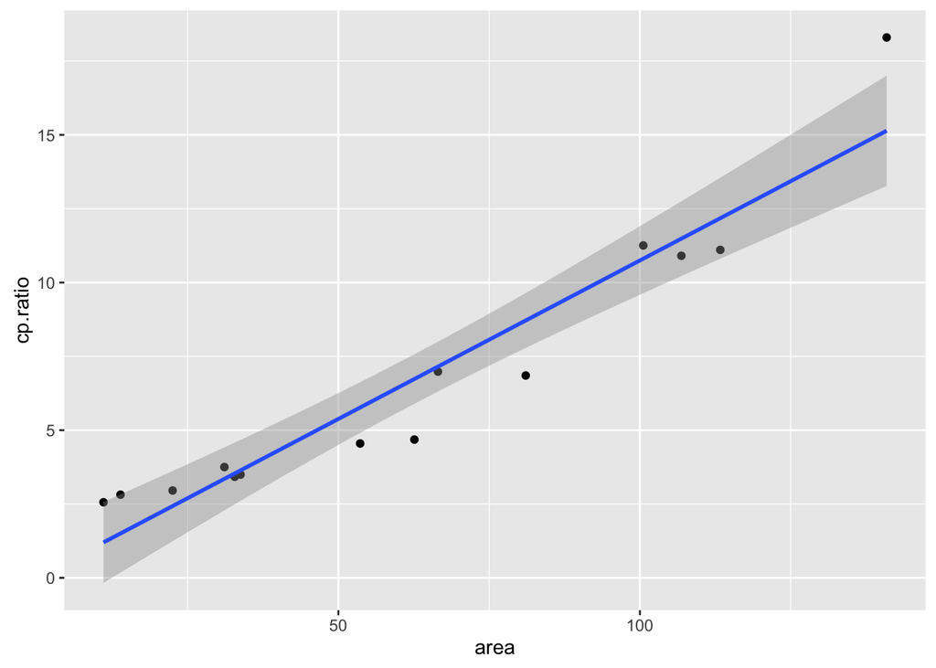

```r
ganglion.gg + geom_smooth(method="lm")
```

We could look more carefully at the residuals, but it seems clear that the loess curve provides a better fit. (Note also there’s no straight line that goes through the entire loess confidence band.)

If a straight line doesn’t work and you still want a parametric fit, try a quadratic.

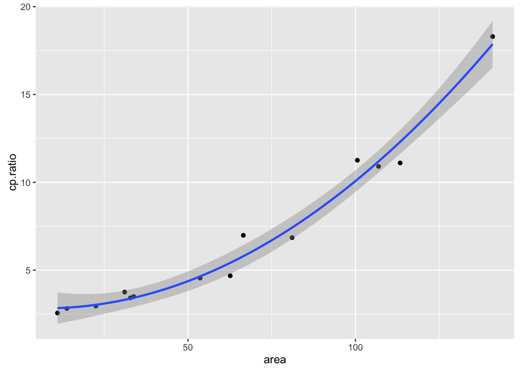

```r
ganglion.gg + geom_smooth(method="lm", formula = y ~ x + I(x^2))
```

The quadratic fit looks more or less the same as the loess fit. The confidence bands are much narrower – they probably underestimate the uncertainty unless we have strong reason to believe the parametric model is correct.

### The broom library and augment()

The `augment()` function within the `broom` library (which you should install) puts fitted values and residuals, among other things, into a convenient data frame. Let’s fit a linear model and try it out:

```r
ganglion.lm = lm(cp.ratio ~ area, data=ganglion)
# install.packages(broom)
library(broom)
gang.lm.df = augment(ganglion.lm)
summary(gang.lm.df)
```

```
##     cp.ratio           area           .fitted          .se.fit
##  Min.   : 2.560   Min.   : 11.05   Min.   : 1.200   Min.   :0.3851
##  1st Qu.: 3.441   1st Qu.: 31.52   1st Qu.: 3.397   1st Qu.:0.4386
##  Median : 4.616   Median : 58.10   Median : 6.251   Median :0.5132
##  Mean   : 6.688   Mean   : 62.18   Mean   : 6.688   Mean   :0.5303
##  3rd Qu.: 9.925   3rd Qu.: 95.68   3rd Qu.:10.284   3rd Qu.:0.6013
##  Max.   :18.300   Max.   :140.92   Max.   :15.139   Max.   :0.8580
##      .resid             .hat             .sigma          .cooksd
##  Min.   :-2.0509   Min.   :0.07144   Min.   :0.9262   Min.   :0.0004336
##  1st Qu.:-0.9493   1st Qu.:0.09286   1st Qu.:1.4356   1st Qu.:0.0065309
##  Median :-0.1277   Median :0.12714   Median :1.4770   Median :0.0249937
##  Mean   : 0.0000   Mean   :0.14286   Mean   :1.4258   Mean   :0.1871098
##  3rd Qu.: 0.5072   3rd Qu.:0.17421   3rd Qu.:1.4990   3rd Qu.:0.0870057
##  Max.   : 3.1603   Max.   :0.35459   Max.   :1.5044   Max.   :2.0477601
##    .std.resid
##  Min.   :-1.47721
##  1st Qu.:-0.73058
##  Median :-0.09395
##  Mean   : 0.03741
##  3rd Qu.: 0.38008
##  Max.   : 2.73029
```

We plot the residuals against the explanatory variable, then add a loess curve. If the confidence band contains the line $y = 0$, then maybe the model is fitting well.

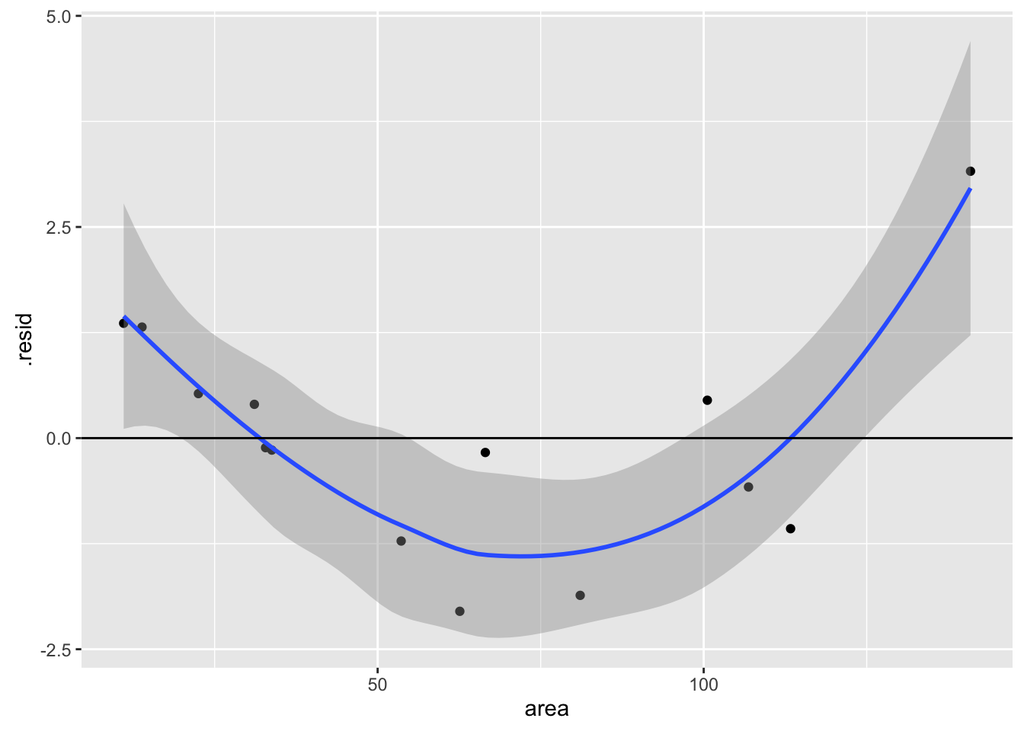

```r
ggplot(gang.lm.df, aes(x=area, y=.resid)) + geom_point() + geom_smooth() +
  geom_abline(slope=0, intercept=0)
```

There’s a clear curve in the residuals, so the linear model doesn’t fit.

Let’s try the quadratic:

```r
ganglion.lm2 = lm(cp.ratio ~ area + I(area^2), data=ganglion)
gang.lm2.df = augment(ganglion.lm2)
summary(gang.lm2.df)
```

```
##     cp.ratio           area          I.area.2.          .fitted
##  Min.   : 2.560   Min.   : 11.05   Min.   :  122.1   Min.   : 2.840
##  1st Qu.: 3.441   1st Qu.: 31.52   1st Qu.:  994.3   1st Qu.: 3.329
##  Median : 4.616   Median : 58.10   Median : 3396.3   Median : 5.029
##  Mean   : 6.688   Mean   : 62.18   Mean   : 5430.5   Mean   : 6.688
##  3rd Qu.: 9.925   3rd Qu.: 95.68   3rd Qu.: 9226.8   3rd Qu.: 9.477
##  Max.   :18.300   Max.   :140.92   Max.   :19857.9   Max.   :17.863
##     .se.fit           .resid              .hat            .sigma
##  Min.   :0.2346   Min.   :-1.19758   Min.   :0.1107   Min.   :0.6081
##  1st Qu.:0.2683   1st Qu.:-0.28029   1st Qu.:0.1448   1st Qu.:0.6907
##  Median :0.2860   Median :-0.05893   Median :0.1644   Median :0.7283
##  Mean   :0.3130   Mean   : 0.00000   Mean   :0.2143   Mean   :0.7030
##  3rd Qu.:0.3051   3rd Qu.: 0.34532   3rd Qu.:0.1872   3rd Qu.:0.7393
##  Max.   :0.6052   Max.   : 1.19049   Max.   :0.7363   Max.   :0.7396
##     .cooksd            .std.resid
##  Min.   :0.0001503   Min.   :-1.88857
##  1st Qu.:0.0008978   1st Qu.:-0.47249
##  Median :0.0288280   Median :-0.09404
##  Mean   :0.1611383   Mean   : 0.02964
##  3rd Qu.:0.1569547   3rd Qu.: 0.52490
##  Max.   :1.3513989   Max.   : 1.84998
```

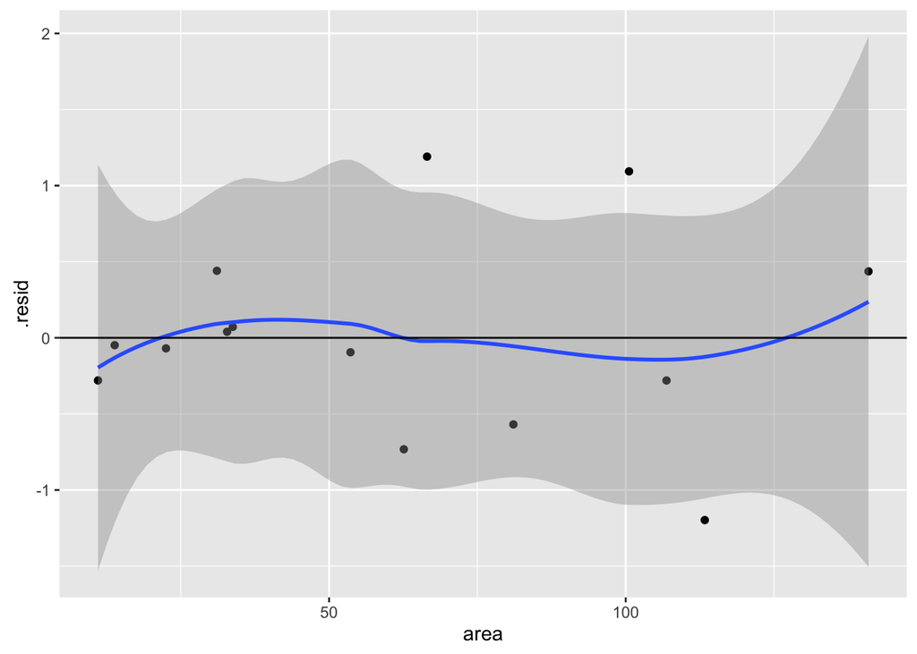

```r
ggplot(gang.lm2.df, aes(x=area, y=.resid)) + geom_point() + geom_smooth() +
  geom_abline(slope=0, intercept=0)
```

The curve for the residuals just wiggles around 0. It’s plausible that the quadratic model is correctly specified.

In addition, we check for homoscedasticity using a spread-location plot.

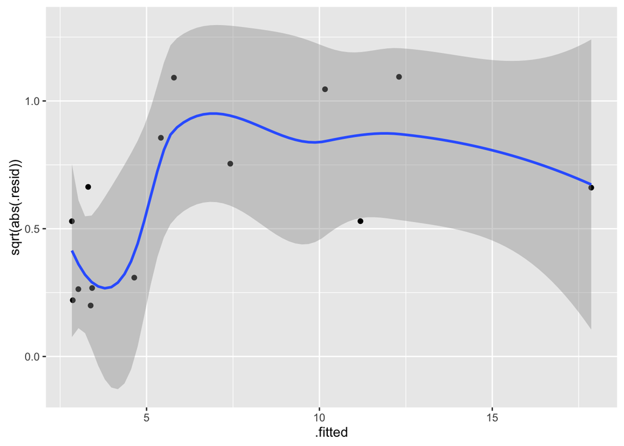

```r
ggplot(gang.lm2.df, aes(x=.fitted, y=sqrt(abs(.resid)))) + geom_point() + geom_smooth()
```

It doesn’t look like a horizontal line describes the transformed residuals well. The spread of the residuals changes with the fitted values, meaning there’s heteroscedasticity. This makes the quadratic model less appealing – maybe a transformation would be better.

Let’s try taking the log of the CP ratio. Add a loess fit:

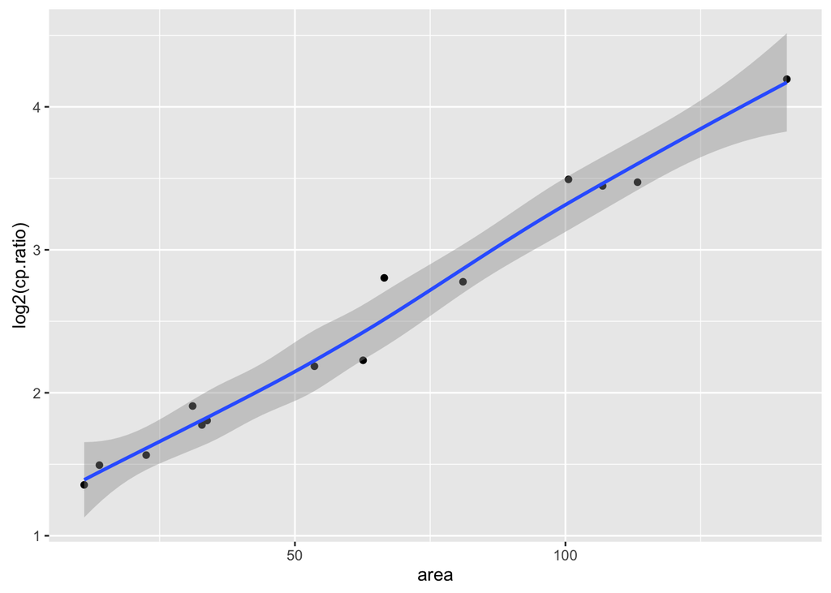

```r
ggplot(ganglion, aes(x=area, y=log2(cp.ratio))) + geom_point() + geom_smooth()
```

Looks like a straight line would do just as good a job. Let’s use `lm()` to fit the model instead.

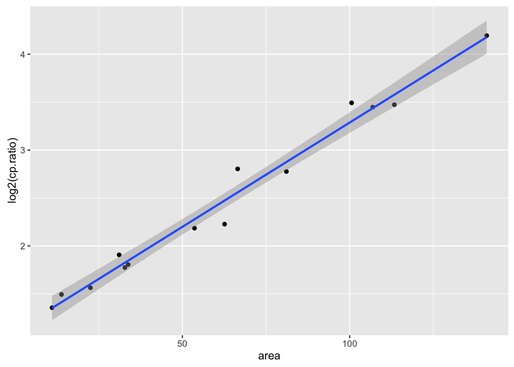

```r
ggplot(ganglion, aes(x=area, y=log2(cp.ratio))) + geom_point() + geom_smooth(method = "lm")
```

The straight line produced by `lm()` looks more or less the same as the loess fit. So far, so good. To get a better look, plot the residuals agaisnt `area`, the $x$-variable.

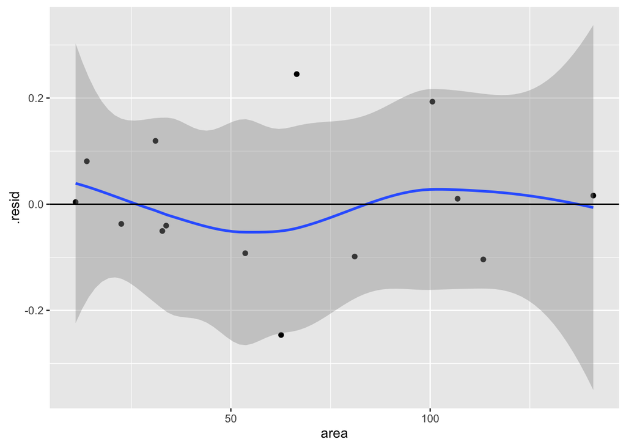

```r
ganglion.log.lm = lm(log2(cp.ratio) ~ area, data=ganglion)
gang.log.lm.df = augment(ganglion.log.lm)
ggplot(gang.log.lm.df, aes(x=area, y=.resid)) + geom_point() + geom_smooth() +
  geom_abline(slope=0, intercept=0)
```

The curve just wiggles around zero. The residuals look like noise. Now check for homoscedasticity using a spread-location plot:

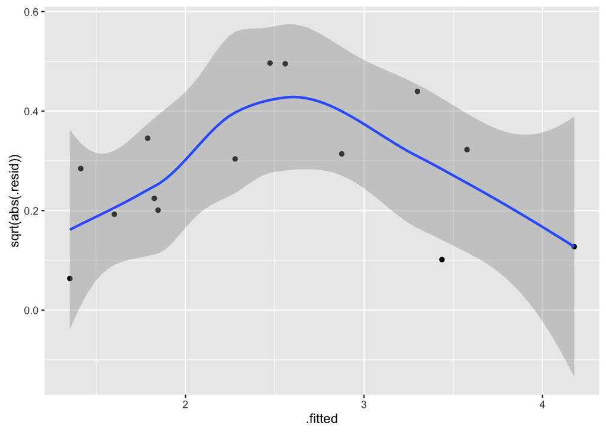

```r
ggplot(gang.log.lm.df, aes(x=.fitted, y=sqrt(abs(.resid)))) + geom_point() + geom_smooth()
```

This time we see a horizontal line goes through the confidence band, so homoscedasticity is a reasonable assumption. (The blue line is curved, but that could just be because of the small amount of data.)

Taking the log of `cp.ratio` has led to an elegant model: linear and homoscedastic. But how much does the model actually explain? Draw a residual-fit plot:

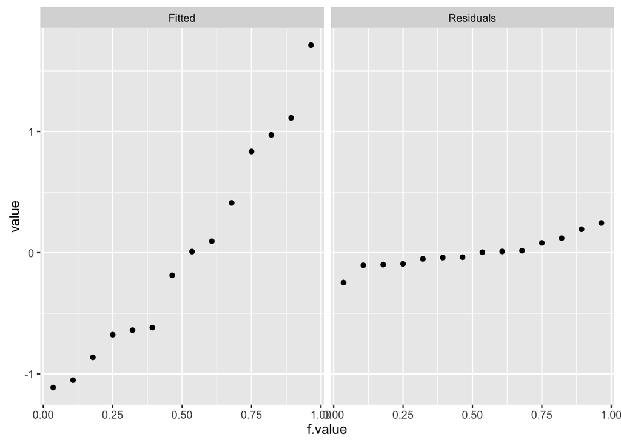

```r
n = nrow(gang.log.lm.df)
f.value = (0.5:(n - 0.5)) / n
gang.log.fit = data.frame(f.value, Fitted = sort(gang.log.lm.df$.fitted) - mean(gang.log.lm.df$.fitted), Residuals = sort(gang.log.lm.df$.resid))
library(tidyr)
gang.log.fit.long = gang.log.fit %>% gather(type, value, Fitted:Residuals)
ggplot(gang.log.fit.long, aes(x=f.value, y=value)) +
  geom_point() + facet_wrap(~type)
```

Finally, we check if the residuals look normal. If so, this would be good, but it wouldn’t necessarily be a dealbreaker if they weren’t.

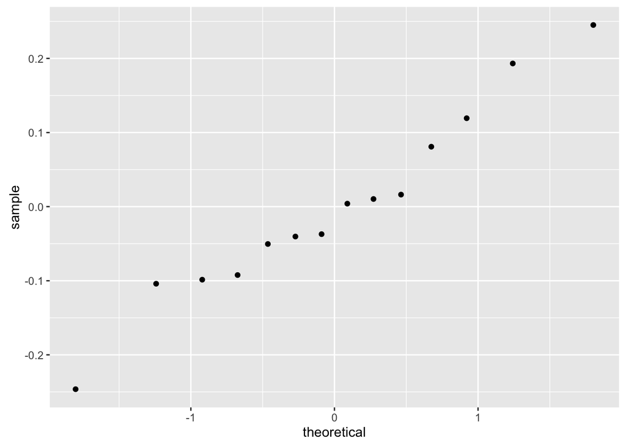

```r
ggplot(gang.log.lm.df, aes(sample=.resid)) + stat_qq()
```